# Analýza citlivosti povodí na změnu klimatu

Martin Hanel et al.

7 února 2018

## Úvod

Balík umožňuje posoudit citlivost povodí na změnu klimatu. Citlivost je vyhodnocena jako reakce povodí na změnu průměrných srážek a teploty. Sezónní cyklus změn je uvažován na základě mediánu standardizovaných sezónních změn z CORDEX simulací. Intenzita sezónního cyklu (směrodatná odchylka sezónních změn, která je použita ke zpětnému škálování standardizovaných změn) je dalším z vyhodnocovaných faktorů působících na změnu hydrologických poměrů. Balík umožňuje vyhodnocení změn základních hydrologických veličin i charakteristik virtuálních nádrží umístěných v závěrovém profilu povodí.

## Základní strategie vyhodnocení

Jelikož uvažujeme vliv změn průměrů a směrodatných odchylek srážek a teploty na hydrologické charakteristiky je problém z hlediska vstupů 4dimenzionální. Abychom zrychlili vyhodnocení kombinací vstupů a zároveň za účelem poskytnutí intuitivní vizualizace, probíhá analýza dvěma způsoby:

- pro zadanou průměrnou změnu srážek a teploty se zjišťuje citlivost na změnu intenzity sezónního cyklu změn
- pro zadanou intenzitu sezónních změn se zjišťuje citlivost na změnu průměrných srážek a teploty

Balík navíc umožňuje vyhodnocení hydrologických dopadů na základě měsíčních změn z projektu CORDEX (změny jsou zprůměrovány pro ČR - tj. prostorová variabilita změn je zanedbána).

## Demonstrace

### Příprava

- Nahrajeme balík a případně ukázková data (nakalibrovaný model Bilan pro povodí LAPV Amerika)

```r
library(hySens)
data("amerika")
amerika
```

```
## <pointer: 0x557efb513e40>
## attr(,"class")
## [1] "bilan"
## attr(,"vars_class")
## [1] "data.frame"
```

- Nahrajeme měsíční změny srážek a teploty z CORDEX simulací (pro každou dostupnou simulaci, 3 časové horizonty) a 3 scénáře koncentrací uvádí změny měsíčních srážek (`dPR`) a teploty (`dTAS`)

```r
data("delty")
delty
```

```
##       month                                                         SID
##    1:     1 EUR-11_CNRM-CERFACS-CNRM-CM5_rcp45_r1i1p1_CLMcom-CCLM4-8-17
##    2:     2 EUR-11_CNRM-CERFACS-CNRM-CM5_rcp45_r1i1p1_CLMcom-CCLM4-8-17
##    3:     3 EUR-11_CNRM-CERFACS-CNRM-CM5_rcp45_r1i1p1_CLMcom-CCLM4-8-17
##    4:     4 EUR-11_CNRM-CERFACS-CNRM-CM5_rcp45_r1i1p1_CLMcom-CCLM4-8-17
##    5:     5 EUR-11_CNRM-CERFACS-CNRM-CM5_rcp45_r1i1p1_CLMcom-CCLM4-8-17
##   ---
## 1844:     8          EUR-44_NOAA-GFDL-GFDL-ESM2M_rcp85_r1i1p1_SMHI-RCA4
## 1845:     9          EUR-44_NOAA-GFDL-GFDL-ESM2M_rcp85_r1i1p1_SMHI-RCA4
## 1846:    10          EUR-44_NOAA-GFDL-GFDL-ESM2M_rcp85_r1i1p1_SMHI-RCA4
## 1847:    11          EUR-44_NOAA-GFDL-GFDL-ESM2M_rcp85_r1i1p1_SMHI-RCA4
## 1848:    12          EUR-44_NOAA-GFDL-GFDL-ESM2M_rcp85_r1i1p1_SMHI-RCA4
##        PER   EXP       dPR        dTAS
##    1: 2035 rcp45 0.9233480 -0.04756698
##    2: 2035 rcp45 1.0903042  0.40120509
##    3: 2035 rcp45 1.0083391  1.36455466
##    4: 2035 rcp45 0.7693492  0.28615384
##    5: 2035 rcp45 1.1016151  0.41586954
##   ---
## 1844: 2085 rcp85 0.9033387  4.09370068
## 1845: 2085 rcp85 1.0355854  3.56890094
## 1846: 2085 rcp85 1.3557814  2.48016619
## 1847: 2085 rcp85 1.1943990  2.87107055
## 1848: 2085 rcp85 1.2318368  3.95343225
```

- statistiky změn (průměrná roční změna srážek (`meanP`) a teploty (`meanT`), a směrodatná odchylka měsíčních změn srážek (`sdP`) a teploty (`sdT`))

```r
data("stat")
stat
```

```
##                                                              SID  PER
##   1: EUR-11_CNRM-CERFACS-CNRM-CM5_rcp45_r1i1p1_CLMcom-CCLM4-8-17 2035
##   2: EUR-11_CNRM-CERFACS-CNRM-CM5_rcp45_r1i1p1_CLMcom-CCLM4-8-17 2055
##   3: EUR-11_CNRM-CERFACS-CNRM-CM5_rcp45_r1i1p1_CLMcom-CCLM4-8-17 2085
##   4:     EUR-11_CNRM-CERFACS-CNRM-CM5_rcp45_r1i1p1_CNRM-ALADIN53 2035
##   5:     EUR-11_CNRM-CERFACS-CNRM-CM5_rcp45_r1i1p1_CNRM-ALADIN53 2055
##  ---
## 150:                 EUR-44_NCC-NorESM1-M_rcp85_r1i1p1_SMHI-RCA4 2055
## 151:                 EUR-44_NCC-NorESM1-M_rcp85_r1i1p1_SMHI-RCA4 2085
## 152:          EUR-44_NOAA-GFDL-GFDL-ESM2M_rcp85_r1i1p1_SMHI-RCA4 2035
## 153:          EUR-44_NOAA-GFDL-GFDL-ESM2M_rcp85_r1i1p1_SMHI-RCA4 2055
## 154:          EUR-44_NOAA-GFDL-GFDL-ESM2M_rcp85_r1i1p1_SMHI-RCA4 2085
##        EXP    meanP        sdP     meanT       sdT
##   1: rcp45 1.060891 0.15257835 0.4913909 0.4901590
##   2: rcp45 1.040578 0.08670762 1.2389238 0.5504894
##   3: rcp45 1.122265 0.12373226 1.6201798 0.4926268
##   4: rcp45 1.129174 0.12721875 0.2734563 0.3423062
##   5: rcp45 1.177508 0.12738113 1.0004107 0.4819072
##  ---
## 150: rcp85 1.053210 0.07326509 1.9556803 0.4402926
## 151: rcp85 1.105419 0.09099472 3.3219904 0.6751836
## 152: rcp85 1.054104 0.12860565 1.4392490 0.7328087
## 153: rcp85 1.071709 0.13571925 2.3754666 0.8489118
## 154: rcp85 1.129494 0.15497715 3.3362849 0.9246641
```

- medián standardizovaného sezónního cyklu změn (standardizace proběhla tak, že pro každou simulaci byl od měsíčních změn odečten jejich průměr a výsledek byl dělen směrodatnou odchylkou měsíčních změn - `cyc` udává medián ze všech simulací)

```r
data(cyc)
cyc
```

```
##     month         mP         mT
##  1:     1  0.1944806  0.2579162
##  2:     2  0.1986543  0.5986722
##  3:     3  0.3603301  0.1916768
##  4:     4  0.2229583 -0.5777083
##  5:     5  0.1951023 -0.7491077
##  6:     6 -0.4478342 -0.4491043
##  7:     7 -0.8960238  0.3572663
##  8:     8 -0.6281688  0.5995513
##  9:     9 -0.5490507  0.3855662
## 10:    10 -0.1332932 -0.2381824
## 11:    11  0.3339321 -0.4498971
## 12:    12  0.5788151  0.1864618
```

### Výpočet změn dle CORDEX simulací

- funkce `calc_cordex` vezme jako vstup nakalibrovaný model Bilan s spočte změny dle všech CORDEX simulací pro všechny RCP a časové horizonty

```r
res = calc_cordex(amerika)
res
```

```
##                                                       SID  PER   EXP
##     1:                                               CTRL CTRL   obs
##     2:                                               CTRL CTRL   obs
##     3:                                               CTRL CTRL   obs
##     4:                                               CTRL CTRL   obs
##     5:                                               CTRL CTRL   obs
##    ---
## 55796: EUR-44_NOAA-GFDL-GFDL-ESM2M_rcp85_r1i1p1_SMHI-RCA4 2085 rcp85
## 55797: EUR-44_NOAA-GFDL-GFDL-ESM2M_rcp85_r1i1p1_SMHI-RCA4 2085 rcp85
## 55798: EUR-44_NOAA-GFDL-GFDL-ESM2M_rcp85_r1i1p1_SMHI-RCA4 2085 rcp85
## 55799: EUR-44_NOAA-GFDL-GFDL-ESM2M_rcp85_r1i1p1_SMHI-RCA4 2085 rcp85
## 55800: EUR-44_NOAA-GFDL-GFDL-ESM2M_rcp85_r1i1p1_SMHI-RCA4 2085 rcp85
##               DTM         P         RM           BF         I        DR
##     1: 1970-01-15  17.49360 39.1440056 3.532430e+01  3.819706 0.0000000
##     2: 1970-02-15 136.83000 26.5650568 1.993014e+01  6.634912 0.0000000
```

[output cut: 33 more lines]

### Výpočet citlivosti na změnu průměrných srážek a teploty při zadané intenzitě sezónních cyklu změn

- funkce `calc_sens_mean` bere jako vstup nakalibrovaný model Bilan, dalšími argumenty jsou:
- `f`: jako standardní meze pro vyhodnocení citlivosti bere funkce rozsah změn z CORDEX simulací, argument `f` umožňuje tento rozsah zvětšit, či zmenšit, viz `?extendrange`
- `samples`: počet vyhodnocovaných bodů podél jednotlivých os
- `sdP` a `sdT` - intenzita sezónního cyklu - výchozí je průměr z CORDEX simulací

```r
mres = calc_sens_mean(amerika)
mres
```

```
##          SID  PER EXP iP iT        dX          dY        DTM         P
##      1: CTRL CTRL obs  1  1 0.9456633 0.004123399 1970-01-15  16.96600
##      2: CTRL CTRL obs  1  1 0.9456633 0.004123399 1970-02-15 132.77424
##      3: CTRL CTRL obs  1  1 0.9456633 0.004123399 1970-03-15  64.65621
##      4: CTRL CTRL obs  1  1 0.9456633 0.004123399 1970-04-15  66.81518
##      5: CTRL CTRL obs  1  1 0.9456633 0.004123399 1970-05-15  85.82723
##     ---
## 143996: CTRL CTRL obs 20 20 1.3401701 5.929447884 1999-08-15  79.97780
## 143997: CTRL CTRL obs 20 20 1.3401701 5.929447884 1999-09-15  47.79027
## 143998: CTRL CTRL obs 20 20 1.3401701 5.929447884 1999-10-15  42.16591
## 143999: CTRL CTRL obs 20 20 1.3401701 5.929447884 1999-11-15  59.04623
## 144000: CTRL CTRL obs 20 20 1.3401701 5.929447884 1999-12-15  81.88411
##                 RM           BF         I        DR         PET         ET
##      1: 38.9832646 35.324300000  3.658965 0.0000000   0.3420485  0.3420485
##      2: 26.6806740 19.527757024  7.152917 0.0000000   4.1572437  4.1572437
```

[output cut: 33 more lines]

### Výpočet citlivosti na intenzitu sezónního cyklu změn při zadané změně průměrných srážek a teploty

- funkce `calc_sens_sd`
- argumenty jsou obdobné jako u `calc_sens_mean`, s tím že zadáváme
- `meanP` a `meanT` - tj. průměrnou změnu srážek a teploty

```r
ires = calc_sens_sd(amerika)
ires
```

```
##          SID  PER EXP iP iT         dX        dY        DTM         P
##      1: CTRL CTRL obs  1  1 0.03907262 0.2198447 1970-01-15  19.09888
##      2: CTRL CTRL obs  1  1 0.03907262 0.2198447 1970-02-15 149.40838
##      3: CTRL CTRL obs  1  1 0.03907262 0.2198447 1970-03-15  71.69239
##      4: CTRL CTRL obs  1  1 0.03907262 0.2198447 1970-04-15  75.01768
##      5: CTRL CTRL obs  1  1 0.03907262 0.2198447 1970-05-15  96.61147
##     ---
## 143996: CTRL CTRL obs 20 20 0.35673017 1.7631739 1999-08-15  54.50308
## 143997: CTRL CTRL obs 20 20 0.35673017 1.7631739 1999-09-15  33.37662
## 143998: CTRL CTRL obs 20 20 0.35673017 1.7631739 1999-10-15  33.02346
## 143999: CTRL CTRL obs 20 20 0.35673017 1.7631739 1999-11-15  51.42255
## 144000: CTRL CTRL obs 20 20 0.35673017 1.7631739 1999-12-15  74.83991
##                 RM           BF          I         DR        PET        ET
##      1: 38.9366411 3.532430e+01  3.6123411  0.0000000   2.686760  2.686760
##      2: 28.9858310 1.941104e+01  9.5747877  0.0000000   7.240694  7.240694
```

[output cut: 33 more lines]

## Vyhodnocení

```r
dRM = stats(bilan = amerika, MEAN = mres, SD = ires, CORDEX = res, fun = mean, var = 'RM', type = season, diff_type = "multiplicative")
```

parametry funkce:

- `bilan`: nakalibrovaný model
- `MEAN`: vyhodnocení citlivosti na změnu průměru
- `SD`: vyhodnocení citlivosti na změnu intenzity sezónních cyklu změn
- `CORDEX`: simulace pro scénáře na základě CORDEX simulací
- `fun`: použitá funkce
- `var`: použitá proměnná
- `type`: funkce pro agregaci změn - např. `annual` - roční změny, `season` - sezónní změny, `month` - měsíční změny
- `diff_type`: mají se změny počítat jako podíl (`multiplicative`) nebo rozdíl (`additive`)?

### Změny průměrného průtoku

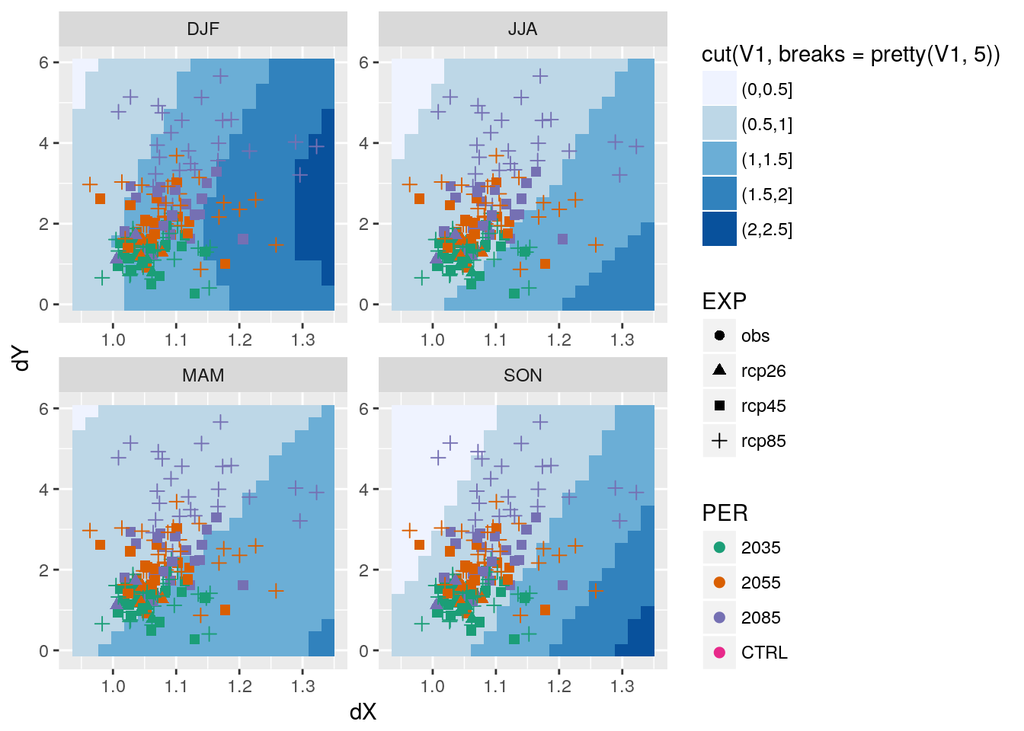

```r
ggplot(dRM[SENS=="MEAN"]) + geom_tile(aes(x = dX, y = dY, fill = cut(V1, breaks = pretty(V1, 5)) )) + facet_wrap(~SEASON , scale="free") + scale_fill_brewer() + geom_point(aes(x = meanP, y = meanT, col = PER, shape = EXP), data = dRM[SENS=='CORDEX'], size = 2) + scale_color_brewer(palette = 'Dark2')
```

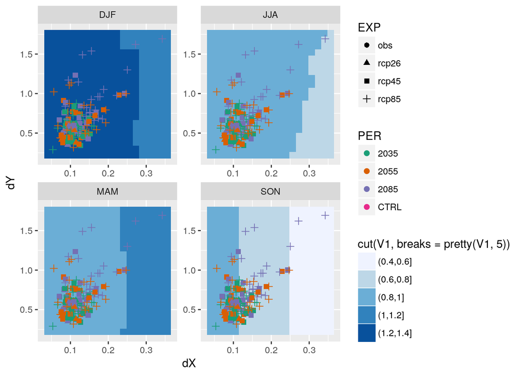

```r
ggplot(dRM[SENS=="SD"]) + geom_tile(aes(x = dX, y = dY, fill = cut(V1, breaks = pretty(V1, 5)) )) + facet_wrap(~SEASON, scale="free") + scale_fill_brewer()+ geom_point(aes(x = sdP, y = sdT, col = PER, shape = EXP), data = dRM[SENS=='CORDEX'], size = 2) + scale_color_brewer(palette = 'Dark2')
```

### Změny nízkých průtoků (v mm)

```r
dRM = stats(bilan = amerika, MEAN = mres, SD = ires, CORDEX = res, fun = function(x)quantile(x, .1), var = 'RM', type = season, diff_type = "additive")
```

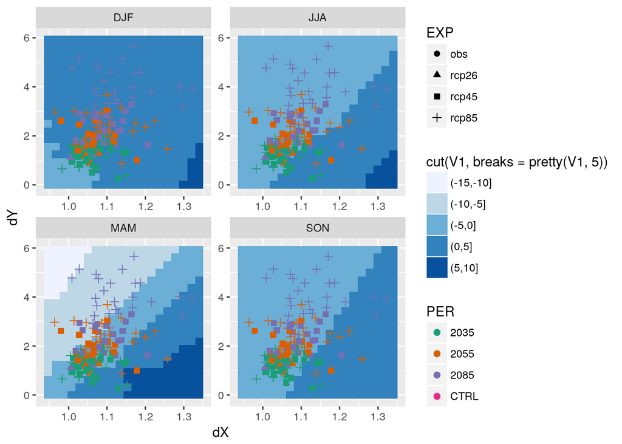

```r
ggplot(dRM[SENS=="MEAN"]) + geom_tile(aes(x = dX, y = dY, fill = cut(V1, breaks = pretty(V1, 5)) )) + facet_wrap(~SEASON , scale="free") + scale_fill_brewer() + geom_point(aes(x = meanP, y = meanT, col = PER, shape = EXP), data = dRM[SENS=='CORDEX'], size = 2) + scale_color_brewer(palette = 'Dark2')
```

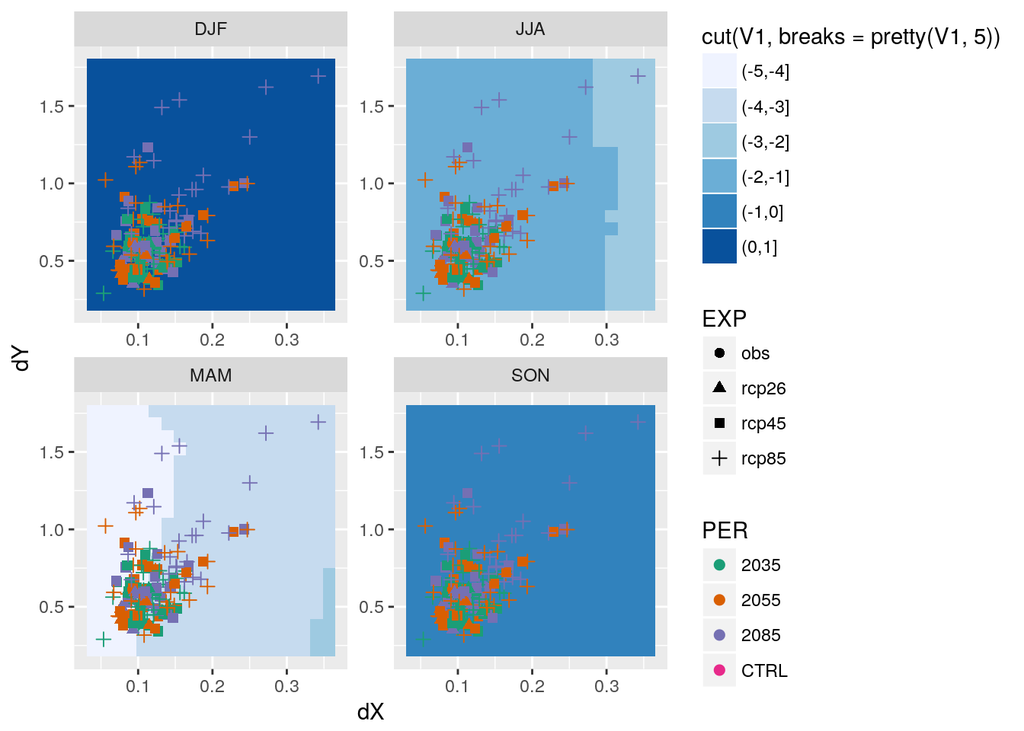

```r
ggplot(dRM[SENS=="SD"]) + geom_tile(aes(x = dX, y = dY, fill = cut(V1, breaks = pretty(V1, 5)) )) + facet_wrap(~SEASON, scale="free") + scale_fill_brewer()+ geom_point(aes(x = sdP, y = sdT, col = PER, shape = EXP), data = dRM[SENS=='CORDEX'], size = 2) + scale_color_brewer(palette = 'Dark2')
```